# Report on Body mass index(BMI)

Author

William Lang, Freya Lynn, Abbey O’Donnell, Soultan Albarghouth

# 1 Introduction

Body mass index(BMI) is an important variable in determing how healthy an indivdual is and is affected by such variables as diet and exercise. The following report will through stastical analysis answer the questions of intrest:

1. Has the body mass index (BMI) in Scotland changed over the given years of the Scottish Health Survey?
2. Are there any differences in the BMI distribution by age, gender, socio-economic status or lifestyle factors?

# 2 Exploratory Analysis

Table 1: Mean, median and standard deviation (sd) of BMI by year.

Mean,Median and standard deviation of BMI by year

| Year | Mean | Median | Standard deviation |
| --- | --- | --- | --- |
| 2016 | 28.03 | 27.28 | 5.79 |
| 2015 | 28.02 | 27.26 | 5.53 |
| 2014 | 27.84 | 27.17 | 5.21 |
| 2013 | 27.81 | 27.08 | 5.28 |

Therefore we can clearly see that the mean and median BMI has slightly increased over the years from 2013-2016. We can also see that the variation has also slightly increased from 2014-2016.

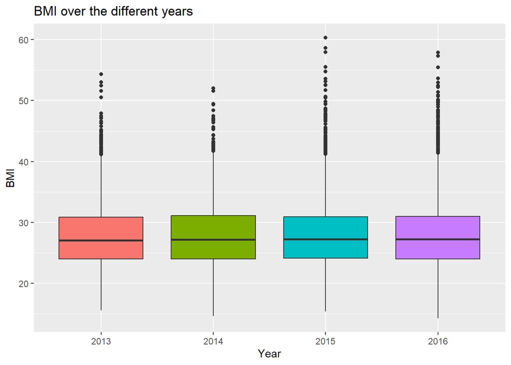

We can therefore see from the boxplots that there is a slight increase in BMI over the years and that the normality assumption is not vaild due to the number of outliers in the data.

## 2.1 Analyzing BMI Distribution by Different Factors

### 2.1.1 Age

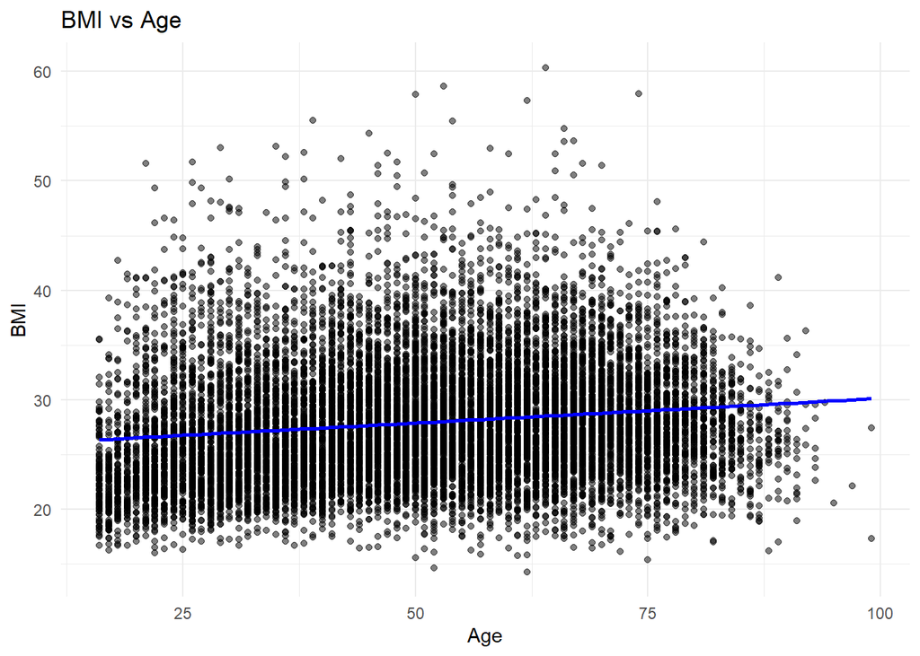

Figure 1: The linear relation ship between Age and BMI

From Figure 1 we can see that there is a weak linear relation between age and BMI.

### 2.1.2 Gender

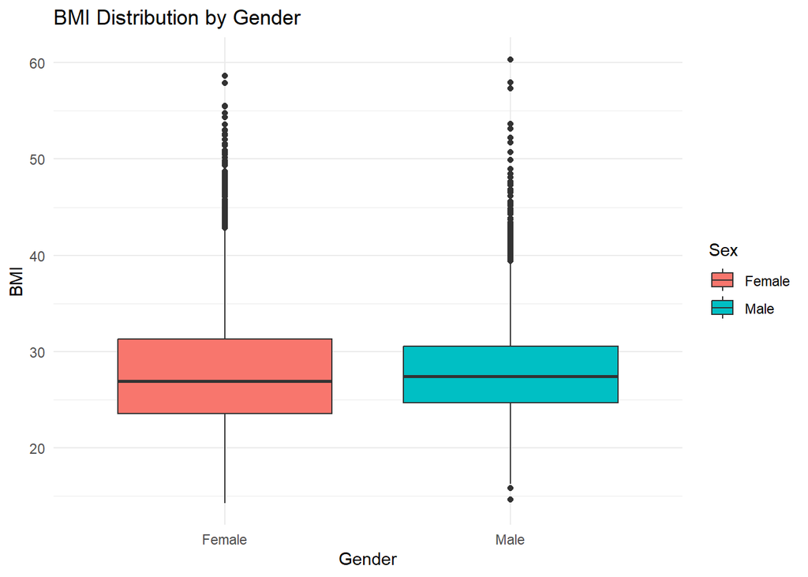

Figure 2: The boxplot of the Sex VS BMI

### 2.1.3 Education

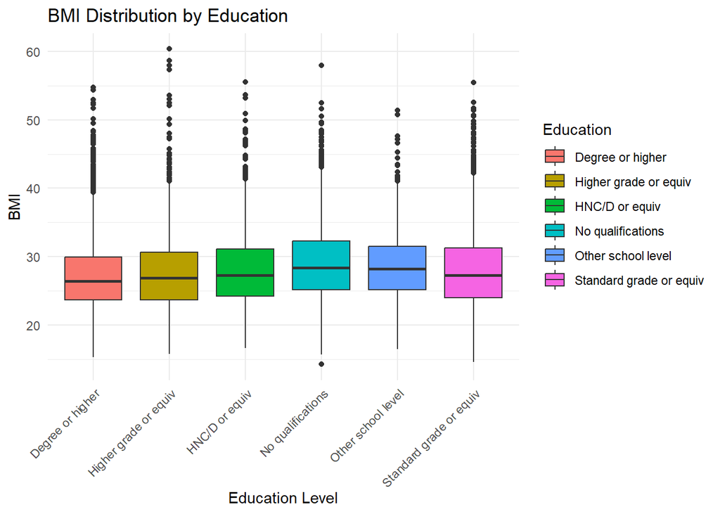

Figure 3: BMI Distribution by Education

From Figure 3 we can see that the small different in medians suggest a minor impact of education on BMI. However the variation on boxplots spreads,indicates that higher education levels might be associated with lower BMI variability. The normality assumption may not be satisfied due to outliers in the data.

### 2.1.4 Fruit and Veg

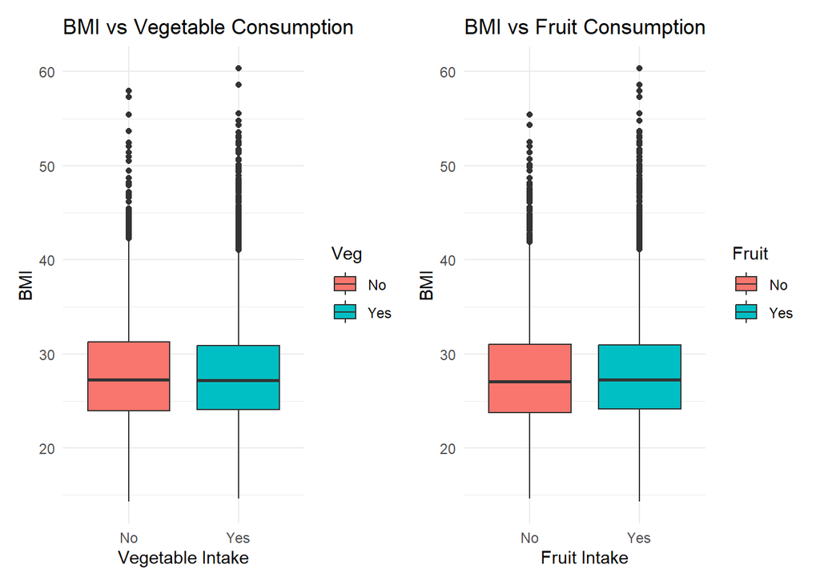

Figure 4

From Figure 4 since both fruit and vegetarian have similar boxplots and median,it suggest that neither of them significantly effect BMI distribution. This indicates that BMI is similar regardless of whether a person having a fruit or vegetable. The normality assumption may not be satisfied due to outliers in the data.

# 3 Formal Analysis

## 3.1 Question 1

To determine whether BMI has changed in Scotland over the given years, we fit a regression model, where BMI is our outcome variable y and Year is our categorical variable x :

```
parsnip model object


Call:
stats::lm(formula = BMI ~ Year, data = data)

Coefficients:
(Intercept)     Year2014     Year2015     Year2016
   27.81034      0.02872      0.21339      0.22322
```

Model output of BMI against year

| Intercept | Year2014 | Year2015 | Year2016 |
| --- | --- | --- | --- |
| 27.81034 | 0.02872 | 0.21339 | 0.22322 |

We can interpret the estimates as follows: Intercept: This tells us that when the year is 2013 the BMI of an individual is expected to be 27.81034.

Year2014: This tells us that when the year is 2014 there is an associated an increase of,on average of 0.02872 in BMI of an individual.

Year2015: This tells us that when the year is 2015 there is an associated an increase of,on average of 0.21339 in BMI of an individual.

Year2016: This tells us that when the year is 2016 there is an associated an increase of,on average of 0.22322 in BMI of an individual.

We can use the estimates obtained here to fit our regression equation as follows:

$$BMI = \alpha + \beta_{2014}\cdot I_{2014}(x) +\beta_{2015}\cdot I_{2015}(x)+\beta_{2016}\cdot I_{2016}(x)$$

where

- the intercept $\alpha$ is the mean BMI for our baseline year, 2013;
- $\beta_{year}$ is the difference in the mean BMI in a given year relative to the baseline year 2013; and
- $I_{year}(x)$ is an indicator function such that

  $$I_{year}(x) = \left\{ \begin{array}{rcl}\
  1 & \mbox{if x matches the given year}
  \\ 0 & \mbox{otherwise}
  \end{array}\right.$$

We can now assess the fit of our model.

We first do this by obtaining residuals. These are then plotted by year to test our assumptions:

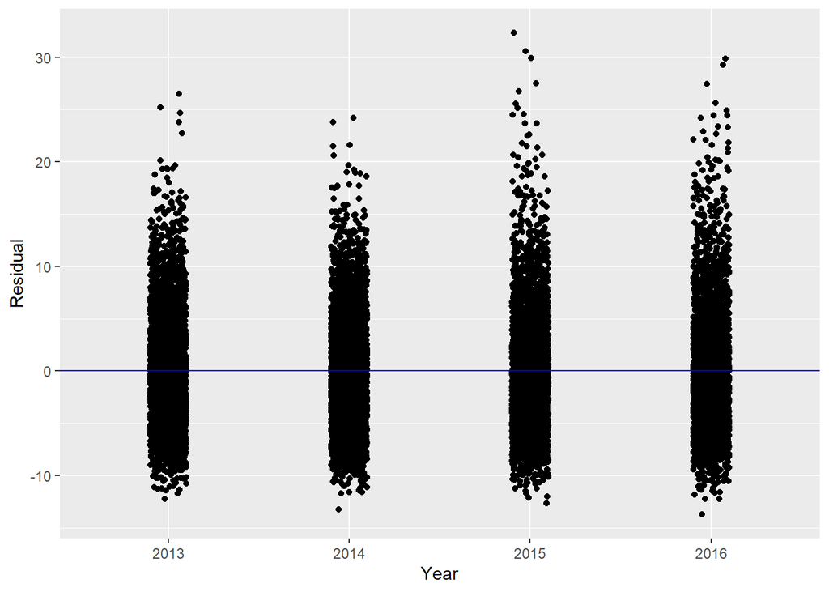

Figure 5: Scatterplot of Residuals by Year

Figure 5 shows that the residuals are evenly spread and have mean zero. Therefore our assumption of constant variance appears to be valid.

We next plot a histogram to check that the residuals are normally distributed:

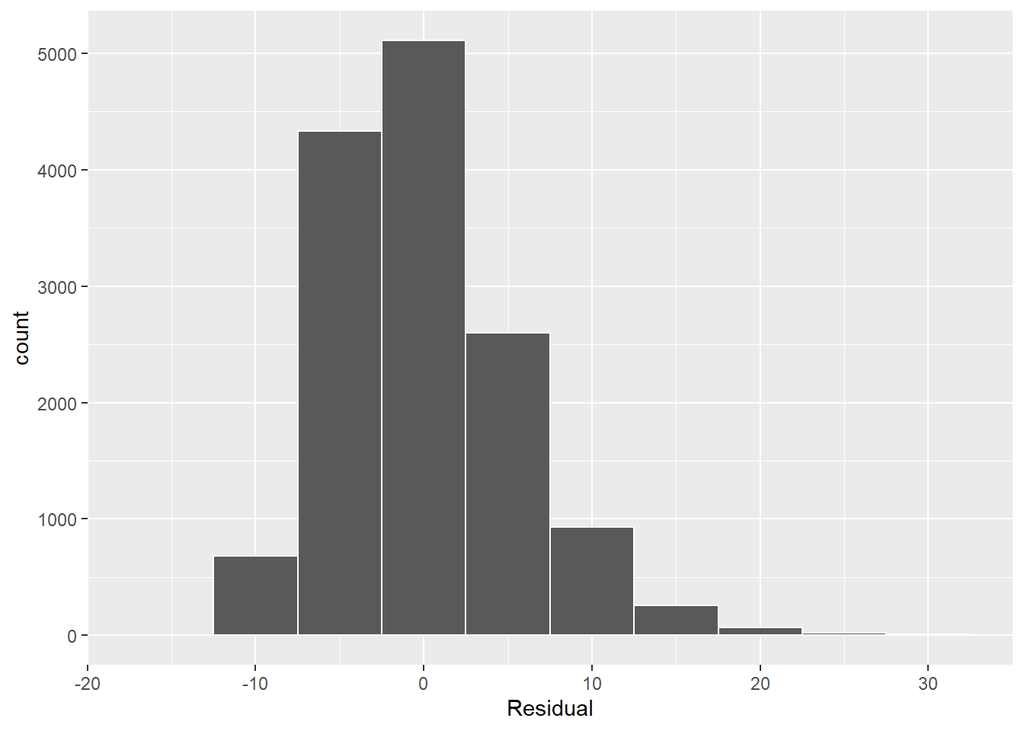

Figure 6: Histogram of Residuals

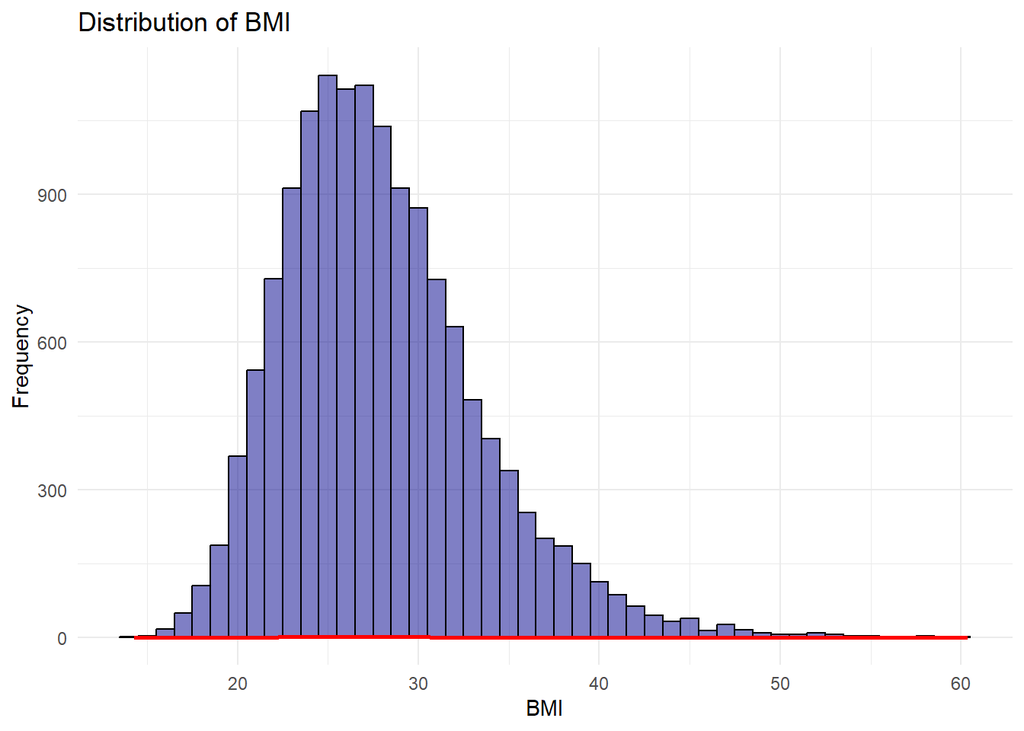

```
# A tibble: 11 × 7
   term                   estimate std_error statistic p_value lower_ci upper_ci
   <chr>                     <dbl>     <dbl>     <dbl>   <dbl>    <dbl>    <dbl>
 1 intercept               -87.5      82.5      -1.06    0.289 -249.      74.3
 2 Age                       0.041     0.003    14.0     0        0.035    0.046
 3 Sex: Male                 0.041     0.092     0.443   0.658   -0.139    0.221
 4 Education: Higher gra…    0.564     0.142     3.98    0        0.287    0.842
 5 Education: HNC/D or e…    1.06      0.154     6.87    0        0.758    1.36
 6 Education: No qualifi…    1.18      0.146     8.09    0        0.894    1.47
 7 Education: Other scho…    0.702     0.218     3.23    0.001    0.276    1.13
 8 Education: Standard g…    0.92      0.134     6.86    0        0.657    1.18
 9 Veg: Yes                 -0.11      0.113    -0.974   0.33    -0.331    0.111
10 Fruit: Yes                0.161     0.104     1.55    0.121   -0.042    0.364
11 Year                      0.056     0.041     1.37    0.172   -0.024    0.136
```

[output not shown]

```
# A tibble: 11 × 7
   term                 estimate std.error statistic  p.value conf.low conf.high
   <chr>                   <dbl>     <dbl>     <dbl>    <dbl>    <dbl>     <dbl>
 1 (Intercept)          -87.5     82.5        -1.06  2.89e- 1 -2.49e+2   74.3
 2 Age                    0.0405   0.00290    14.0   4.74e-44  3.48e-2    0.0462
 3 SexMale                0.0407   0.0918      0.443 6.58e- 1 -1.39e-1    0.221
 4 EducationHigher gra…   0.564    0.142       3.98  6.79e- 5  2.87e-1    0.842
 5 EducationHNC/D or e…   1.06     0.154       6.87  6.88e-12  7.58e-1    1.36
 6 EducationNo qualifi…   1.18     0.146       8.09  6.63e-16  8.94e-1    1.47
 7 EducationOther scho…   0.702    0.218       3.23  1.25e- 3  2.76e-1    1.13
 8 EducationStandard g…   0.920    0.134       6.86  7.33e-12  6.57e-1    1.18
 9 VegYes                -0.110    0.113      -0.974 3.30e- 1 -3.31e-1    0.111
10 FruitYes               0.161    0.104       1.55  1.21e- 1 -4.22e-2    0.364
11 Year                   0.0560   0.0410      1.37  1.72e- 1 -2.44e-2    0.136
```

```
# A tibble: 19 × 7
   term                   estimate std_error statistic p_value lower_ci upper_ci
   <chr>                     <dbl>     <dbl>     <dbl>   <dbl>    <dbl>    <dbl>
 1 intercept              -614.      252.       -2.44    0.015 -1.11e+3 -120.
 2 Age                      10.4       4.70      2.21    0.027  1.19e+0   19.6
 3 Sex: Male                -0.778     0.325    -2.39    0.017 -1.42e+0   -0.141
 4 Education: Higher gra…    0.722     0.191     3.78    0      3.48e-1    1.10
 5 Education: HNC/D or e…    1.16      0.206     5.60    0      7.51e-1    1.56
 6 Education: No qualifi…    1.62      0.194     8.35    0      1.24e+0    2.00
 7 Education: Other scho…    0.879     0.288     3.05    0.002  3.14e-1    1.44
 8 Education: Standard g…    1.21      0.179     6.75    0      8.57e-1    1.56
 9 Veg: Yes                 -0.006     0.171    -0.034   0.973 -3.41e-1    0.329
10 Fruit: Yes                0.299     0.193     1.55    0.121 -7.9 e-2    0.677
11 Year                      0.317     0.125     2.54    0.011  7.2 e-2    0.562
12 Age:SexMale               0.024     0.006     4.12    0      1.2 e-2    0.035
13 Sex: Male:EducationHi…   -0.353     0.284    -1.25    0.213 -9.09e-1    0.202
14 Sex: Male:EducationHN…   -0.225     0.31     -0.725   0.468 -8.33e-1    0.383
15 Sex: Male:EducationNo…   -0.976     0.288    -3.39    0.001 -1.54e+0   -0.411
16 Sex: Male:EducationOt…   -0.317     0.438    -0.722   0.47  -1.18e+0    0.543
17 Sex: Male:EducationSt…   -0.625     0.267    -2.34    0.019 -1.15e+0   -0.101
18 Veg: Yes:FruitYes        -0.188     0.225    -0.836   0.403 -6.3 e-1    0.253
19 Age:Year                 -0.005     0.002    -2.21    0.027 -1   e-2   -0.001
```

```
# A tibble: 2 × 3
  model                AIC    BIC
  <chr>              <dbl>  <dbl>
1 Full Model        86927. 87018.
2 Interaction Model 86910. 87061.
```

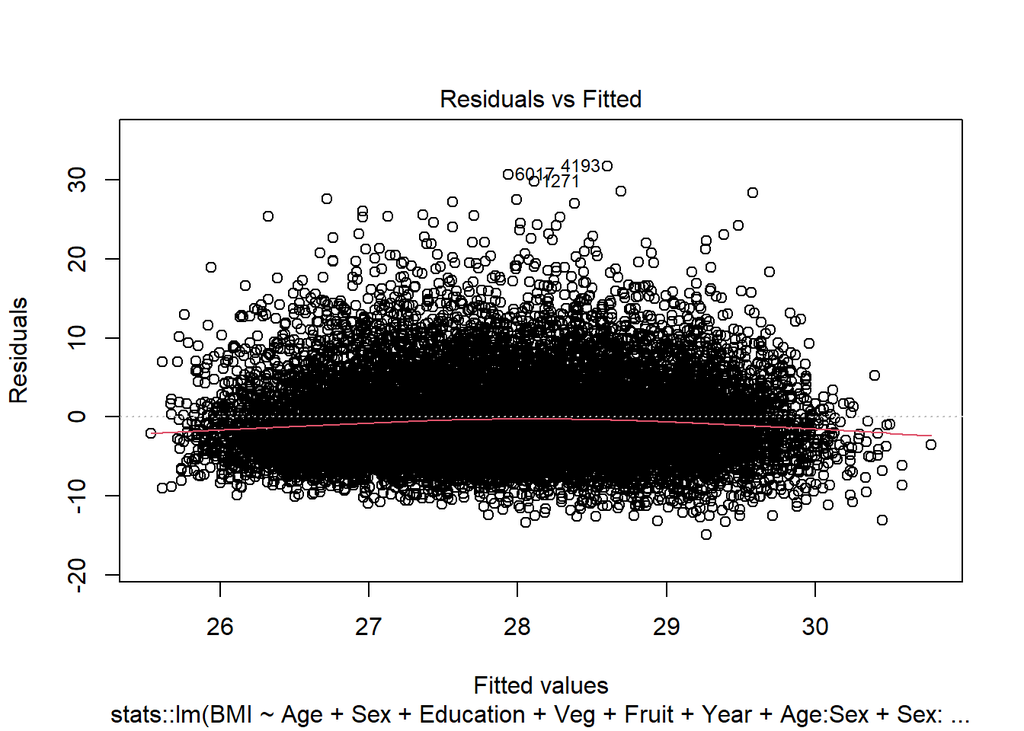

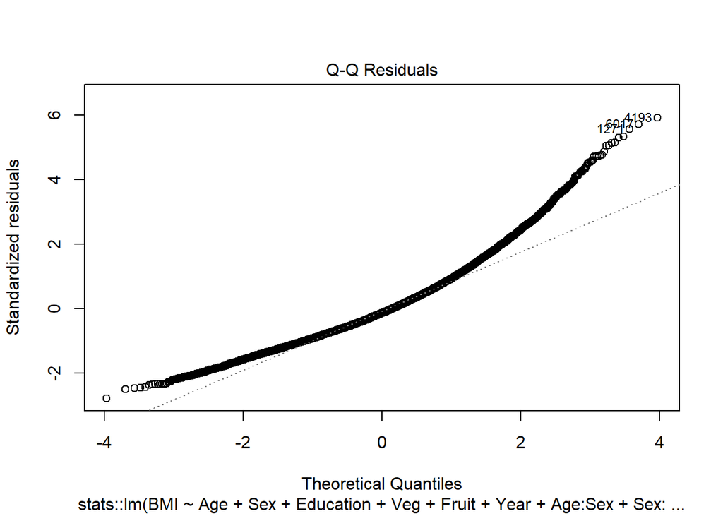

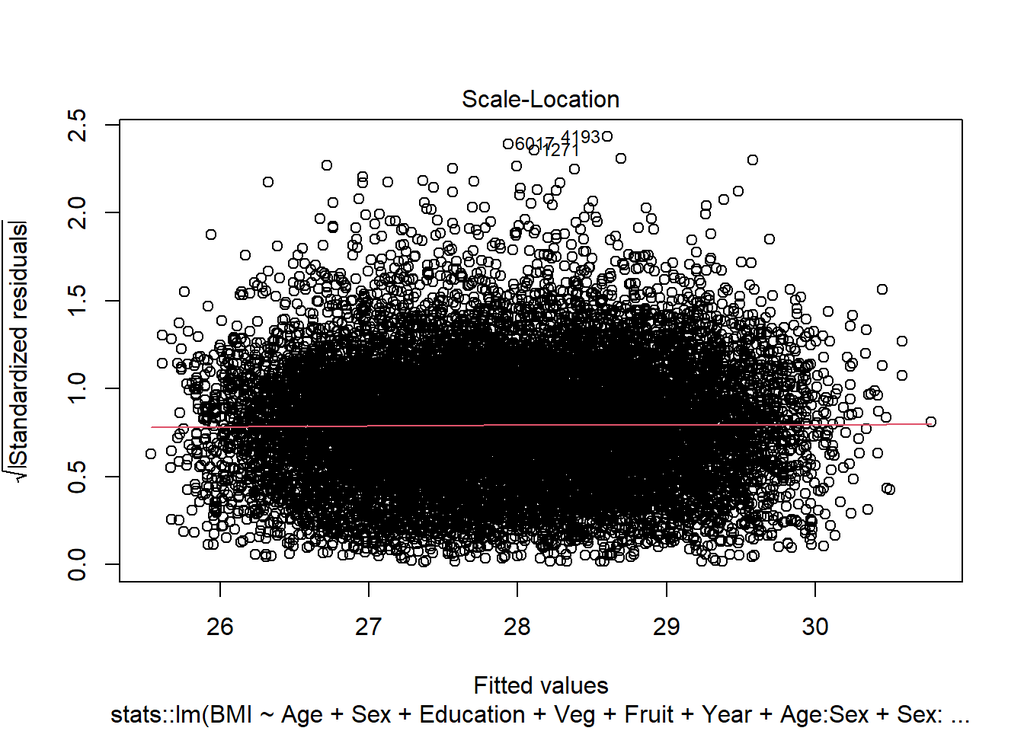

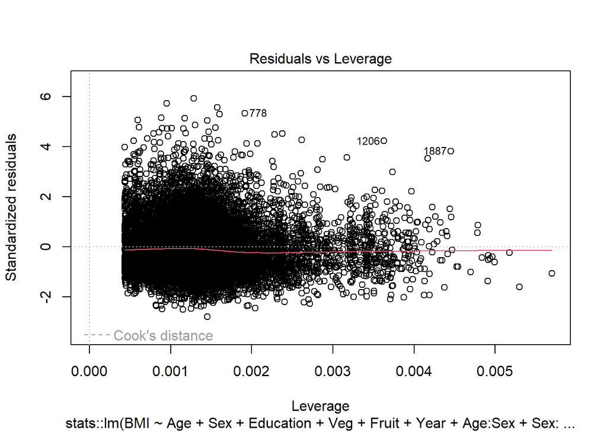

# 4 Conclusions

In conclusion, the analysis of BMI in Scotland from 2013 to 2016 shows only slight difference over the years,indicating a stability in BMI levels during this period.

The interaction effects reveal complex relationships between these factors, showing how multiple variables jointly influence BMI distribution.